# Utah SDM Workshop troubleshooting and data prep

Prep and planning for SDM workshop / demo to deliver to Utah Geography.

This will be based on Dan Griffith’s SDM workshop from OSU in Fall 2017.

Planned modifications include:

```
- Shift to aspens in UT
- Demo BRT alone instead of dismo, runs a little faster
    - or, just run a BRT in dismo
    - Optimize parameters before running

- Include ggmap plotting capabilities
- envStack- bioclim - minus the categorical vars.
```

- Way to make README match the handout? So people can use GitHub
- Have users either clone or just download whole github repo

# Setup

```r
# LOAD LIBRARIES
  #install.packages("here)
    library(here)
  #install.packages("rgeos")
    library(rgeos)
  #install.packages("rgbif")
    library(rgbif)
  #install.packages("maps")
    library(maps)
  #install.packages("maptools")
    library(maptools)
  #install.packages("raster")
    library(raster)
  #install.packages("rgdal")
    library(rgdal)
  #install.packages("biomod2")
    library(biomod2)
  #install.packages("ggplot2")
    library(ggplot2)
  #install.packages("tidyverse")
    library(tidyverse)
```

## Looking for the data - climate data

```r
#climate data
load(here("data/climate/envStack_v2.RData"))
# what's in here?
names(envStack)
```

```
 [1] "Annual.Mean.Temperature"             "Mean.Diurnal.Range"                  "Isothermality"
 [4] "Temperature.Seasonality"             "Max.Temperature.of.Warmest.Month"    "Min.Temperature.of.Coldest.Month"
 [7] "Temperature.Annual.Range"            "Mean.Temperature.of.Wettest.Quarter" "Mean.Temperature.of.Driest.Quarter"
[10] "Mean.Temperature.of.Warmest.Quarter" "Mean.Temperature.of.Coldest.Quarter" "Annual.Precipitation"
[13] "Precipitation.of.Wettest.Month"      "Precipitation.of.Driest.Month"       "Precipitation.Seasonality"
[16] "Precipitation.of.Wettest.Quarter"    "Precipitation.of.Driest.Quarter"     "Precipitation.of.Warmest.Quarter"
[19] "Precipitation.of.Coldest.Quarter"    "elevation"                           "glwd_3"
[22] "GlobCover2009LC"                     "LC_5min_global_2012"
```

```r
names(envStack[[1:20]])
```

```
 [1] "Annual.Mean.Temperature"             "Mean.Diurnal.Range"                  "Isothermality"
 [4] "Temperature.Seasonality"             "Max.Temperature.of.Warmest.Month"    "Min.Temperature.of.Coldest.Month"
 [7] "Temperature.Annual.Range"            "Mean.Temperature.of.Wettest.Quarter" "Mean.Temperature.of.Driest.Quarter"
[10] "Mean.Temperature.of.Warmest.Quarter" "Mean.Temperature.of.Coldest.Quarter" "Annual.Precipitation"
[13] "Precipitation.of.Wettest.Month"      "Precipitation.of.Driest.Month"       "Precipitation.Seasonality"
[16] "Precipitation.of.Wettest.Quarter"    "Precipitation.of.Driest.Quarter"     "Precipitation.of.Warmest.Quarter"
[19] "Precipitation.of.Coldest.Quarter"    "elevation"
```

```r
#export to just be top 20 vars
envStack <- envStack[[1:20]]
saveRDS(envStack, file = here("data/climate/envStack_ForWorkshop.RData"))
#inspect
envStack <- readRDS(here("data/climate/envStack_ForWorkshop.RData"))
envStack
```

```
class       : RasterStack
dimensions  : 385, 691, 266035, 20  (nrow, ncol, ncell, nlayers)
resolution  : 0.1666667, 0.1666667  (x, y)
extent      : -167.6667, -52.5, 7.166667, 71.33333  (xmin, xmax, ymin, ymax)
coord. ref. : +proj=longlat +datum=WGS84 +no_defs +ellps=WGS84 +towgs84=0,0,0
names       : Annual.Mean.Temperature, Mean.Diurnal.Range, Isothermality, Temperature.Seasonality, Max.Tempe//mest.Month, Min.Tempe//dest.Month, Temperature.Annual.Range, Mean.Temp//st.Quarter, Mean.Temp//st.Quarter, Mean.Temp//st.Quarter, Mean.Temp//st.Quarter, Annual.Precipitation, Precipita//test…
min values  :              -17.924594,           0.000000,      6.020826,                0.000000,              0.000000,            -40.266750,                 0.000000,            -15.511111,            -34.296750,             -2.772625,            -34.338291,            11.000000,              2.…
max values  :                29.25243,           23.67045,      92.80939,              1769.72014,              44.31200,              24.08963,                 57.95650,              33.50954,              29.84033,              35.13667,              28.07633,          11191.00000,            2328…
```

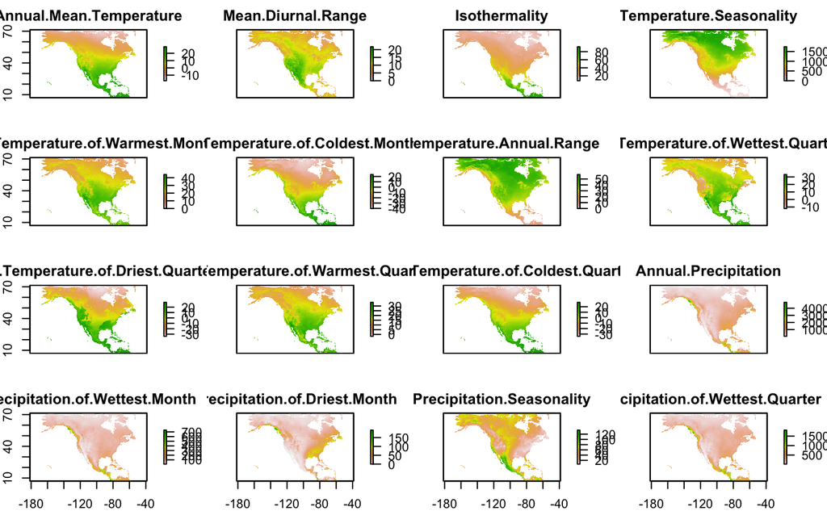

```r
plot(envStack)
```

[figure not shown]

```r
#export
dir.create(path = here("/data/GBIF"))
```

```
'/Users/lilaleatherman/Documents/github/sdm_tutorial_utah//data/GBIF' already exists
```

## Plotting

```r
plot(gbif.POTR[,2:3])
plot(gbif.POTR.shp)
```

```r
#to plot points, run this whole chunk

maps::map(database = "state", regions = "utah")
    points(gbif.POTR.shp)
```

## Get data - get FIA data

sloppy download - where in FIA data are the tree species occurrence data i’m interested in ?

FIA data dictionary located here: https://www.fia.fs.fed.us/library/database-documentation/current/ver80/FIADB%20User%20Guide%20P2_8-0.pdf

```r
dir.create(here("data/FIA"))

#download plot file
url <- "https://apps.fs.usda.gov/fia/datamart/CSV/UT_PLOT.csv"

download.file(url, here("data/FIA/ut_plot.csv"))

ut_plot <- read.csv(here("data/FIA/ut_plot.csv"), stringsAsFactors = FALSE)

#inspect
str(ut_plot)
names(ut_plot)

#download subplot location file
url <- "https://apps.fs.usda.gov/fia/datamart/CSV/UT_SUBPLOT.csv"

download.file(url, here("data/FIA/ut_subplot.csv"))

ut_subplot <- read.csv(here("data/FIA/ut_subplot.csv"), stringsAsFactors = FALSE)

#inspect
names(ut_subplot)

#download veg subplot file
url <- "https://apps.fs.usda.gov/fia/datamart/CSV/UT_P2VEG_SUBPLOT_SPP.csv"

download.file(url, here("data/FIA/ut_spp.csv"))

ut_spp <- read.csv(here("data/FIA/ut_spp.csv"), stringsAsFactors = FALSE)

names(ut_spp)
```

```r
# load in FIA data tables only

ut_plot <- read.csv(here("data/FIA/ut_plot.csv"), stringsAsFactors = FALSE)
ut_subplot <- read.csv(here("data/FIA/ut_subplot.csv"), stringsAsFactors = FALSE)
ut_spp <- read.csv(here("data/FIA/ut_spp.csv"), stringsAsFactors = FALSE)
```

[output not shown]

[output cut: 990 more lines]

```r
# read shapefile back in

fia.POTR.shp <- raster::shapefile(here("data/FIA/fia.POTR.shp"))

#inspect
#plot(fia.POTR, col = presAbs)

#fia.POTR
```

Load prelim map data

```r
#load map data
states_us <- map_data("state")

UT <- subset(states_us, region %in% c("utah"))

fia_df %>%
  group_by(PLOT) %>%
  filter(VEG_SPCD == "POTR5") %>%
ggplot() +
      geom_polygon(data = UT, aes(x=long, y = lat, group = group), fill = NA, color = "black") +
      geom_point( aes(x = LON, y = LAT), color = "red") +
      coord_fixed(1.3) +
      labs(title = "FIA POTR5 PRESENCE DATA")

fia_df %>%
  group_by(PLOT) %>%
  mutate(POTR5_presAbs = ifelse(VEG_SPCD %in% c("POTR5"), 1, 0)) %>%
  arrange(PLOT) %>%
  select(PLOT, VEG_SPCD, COVER_PCT, POTR5_presAbs, LON, LAT) %>%
  distinct(PLOT, POTR5_presAbs, LON, LAT) %>%
  arrange(POTR5_presAbs) %>%
ggplot() +
      geom_polygon(data = UT, aes(x=long, y = lat, group = group), fill = NA, color = "black") +
      geom_point( aes(x = LON, y = LAT, color = factor(POTR5_presAbs))) +
      coord_fixed(1.3) +
      labs(title = "FIA POTR5 PRESENCE DATA")
```

```r
# make GBIF and FIA data play with each other

#FIA data already have presence-absence data, need to add it for GBIF

gbif.POTR.shp@data <- data.frame(gbif.POTR.shp@data,
                                 presAbs = rep(1, nrow(gbif.POTR.shp)))

# bind these together
POTR.dat <- bind_rows(fia.POTR.shp@data, gbif.POTR.shp@data) %>%
  select(lon, lat, presAbs) # filter to only the fields present in both datasets

# since we already have both as data frames, another option is to just bind the original dataframes, and not the data portion of the spatial points data frame

#still have to add presAbs to gbif
gbif.POTR <- gbif.POTR %>%
  mutate(presAbs = 1)

POTR.dat.2 <- bind_rows(fia.POTR, gbif.POTR) %>%
  select(lon, lat, presAbs)

# plot all together

ggplot() +
      geom_polygon(data = UT, aes(x=long, y = lat, group = group), fill = NA, color = "black") +
      geom_point(data = POTR.dat %>% arrange(presAbs), aes(x = lon, y = lat, color = factor(presAbs))) +
      coord_fixed(1.3) +
      labs(title = "FIA and GBIF PRESENCE/ABSENCE DATA - Populus tremuloides")

plot(gbif.POTR.shp)
```

## load and prep landcover layer to use to mask SDM to forested areas only

```r
landcover <- raster(here("data/ut_landcover/ut_landcover.tif"))

#inspect
plot(landcover)

landcover

summary(landcover)

#list forest landcover classses
# from metadata

forest_classes <- c(23:26, 28:40, 42, 51, 111:112, 121:123, 125)

forest_mask <- landcover %in% forest_classes

plot(forest_mask)

forest_mask_wgs <- projectRaster(forest_mask, crs = crs(envStack_UT),
                                 res = res(envStack_UT))

compareRaster(forest_mask_wgs, envStack_UT)
extent(forest_mask_wgs)
extent(envStack_UT)

forest_mask_wgs <- projectRaster(forest_mask, envStack_UT)

forest_mask_wgs
compareRaster(forest_mask_wgs, envStack_UT)

#export
writeRaster(forest_mask_wgs, here("data/ut_landcover/ut_forestmask.tif"), format = "GTiff", overwrite = TRUE)

#read back in

forest_mask_wgs <- raster(here("data/ut_landcover/ut_forestmask.tif"))

forest_mask_wgs
plot(forest_mask_wgs)
```

## mask data for forest

```r
envStack_mask <- mask(x = envStack_UT, mask = forest_mask_wgs)

plot(envStack_mask)
```

```r
gbif.POTR.shp@data <- data.frame(presAbs = rep(1, nrow(gbif.POTR.shp)))
fia.POTR.shp@data <- data.frame(presAbs = fia.POTR.shp@data$presAbs)

POTR.dat.shp <- rbind(fia.POTR.shp, gbif.POTR.shp)

POTR.dat.shp <- spTransform(POTR.dat.shp, proj4string(envStack_UT))

plot(envStack_UT[[1]])
    points(POTR.dat.shp, pch = 21, bg = "white", cex = 0.5)
    points(POTR.dat.shp[POTR.dat.shp$presAbs == 1,], pch = 21, bg = "dodgerblue")
```

```r
## extract enviro data to points

env.dat <- raster::extract(x = envStack_UT, y = POTR.dat.shp)
head(env.dat)
    #plot(env.dat[,2] ~ factor(POTR.dat.shp$presAbs))
```

### Next

```r
POTR.mod.dat <- BIOMOD_FormatingData(resp.var = as.numeric(POTR.dat$presAbs),
                                     resp.xy = POTR.dat[, c("lon", "lat")],
                                     #resp.var = POTR.dat.shp, # for input: can use shapefile with the presence-absence response in the @data slot
                                     expl.var = stack(envStack_UT),
                                     #eval.resp.var = ,
                                     #PA.strategy = "random",
                                     #PA.nb.rep = 0,
                                     #PA.nb.absences = 0,
                                     resp.name = "Populus.tremuloides")
POTR.mod.dat

BIOMOD_ModelingOptions() # need to install java in order to run Maxent.Phillips; we won't be doing this today because it can be pretty finicky!
#myBiomodOptions <- BIOMOD_ModelingOptions(MAXENT.Phillips = list(path_to_maxent.jar = "maxent/maxent.jar"))

POTR.mod <- BIOMOD_Modeling(data = POTR.mod.dat,
                            #models = c('GLM','GAM','ANN','RF','MAXENT.Tsuruoka'),
                            models = c('GBM','ANN','RF'),
                            #SaveObj = TRUE,
                            #models.options = myBiomodOptions,
                            # , DataSplit = 80
                            VarImport = 1)

POTR.mod
```

## Get model evaluations

```r
POTR.mod.eval <- get_evaluations(POTR.mod)
    dimnames(POTR.mod.eval)
    POTR.mod.eval["TSS","Testing.data",,,]
    POTR.mod.eval["KAPPA","Testing.data",,,]
    POTR.mod.eval["ROC","Testing.data",,,]

# prep and plot these data a little more attractively

POTR.mod.eval <-
     data.frame(POTR.mod.eval[1:3, 1:4, ,,]) %>%
       rownames_to_column("metric") %>%
       gather(-metric, key = "mod", value = "val") %>%
       mutate(mod = gsub(pattern = "Testing.data", "Testingdata", mod)) %>%
       separate(mod, c("val_type", "model"))

#inspect evaluation statistics
print(
POTR.mod.eval %>%
  filter(val_type == "Testingdata") %>%
  ggplot(aes(x = metric, y = val, fill = model)) +
  geom_bar(stat = "identity", position = "dodge") +
  theme(axis.text.x = element_text(angle = 90, hjust = 1)) +
  labs(title = "model evaluation - on testing data",
       x = "model type")
)
```

## Get variable importance

```r
get_variables_importance(POTR.mod)
```

We can also prep and plot this a little more attractively.

```r
# investigate variable importance
# still some parsing to do here to visualize
var.imp <- (get_variables_importance(POTR.mod))
var.imp <- data.frame(var.imp)
# var.imp$var <- names(envStack_aoi)
# var.imp

var.imp <-
  var.imp %>%
  mutate(var = names(envStack_UT))%>%
  gather(-var, key = "mod", value = "val") %>%
  separate(mod, c("model_type", "model_level", "data_amt"))

#plot var importance
print(
var.imp %>%
  #mutate(val = ifelse(model_type == "RF", val*10, val)) %>% #multiply RF values by 10 to compare better? idk why these are so low
  ggplot(aes(y = val, x = reorder(var, val), fill = val, group = interaction(data_amt, model_type))) +
  geom_bar(stat = "identity", position = "dodge") +
  coord_flip() +
  theme(axis.text.x = element_text(angle = 90, hjust = 1)) +
  labs(title = "Variable importance, by model",
       x = "variable") +
  facet_grid(~model_type)
)
```

## Create an ensemble model– averaging all of the models together

```r
myBiomodEM <- BIOMOD_EnsembleModeling(
                  modeling.output = POTR.mod,
                  chosen.models = 'all',
                  em.by= 'all',
                  eval.metric = c('TSS'),
                  eval.metric.quality.threshold = c(0.6),
                  prob.mean = T,
                  prob.cv = T,
                  prob.ci = T,
                  prob.ci.alpha = 0.05,
                  prob.median = T,
                  committee.averaging = T,
                  prob.mean.weight = T,
                  prob.mean.weight.decay = 'proportional')

myBiomodEM
get_evaluations(myBiomodEM)
```

## Project the model spatially

```r
myBiomodProj <- BIOMOD_Projection(modeling.output = POTR.mod,
                    new.env = stack(envStack_UT),
                    proj.name = 'current' ,
                    selected.models = 'all' , # will return separate projections for each model
                    binary.meth = 'TSS' ,
                    compress = 'xz' ,
                    clamping.mask = F,
                    output.format = '.grd' )

myBiomodProj

plot(myBiomodProj)
```

```r
plot(myBiomodProj, str.grep = 'RF' )
```

```r
myCurrentProj <- get_predictions(myBiomodProj)

presentResult <- calc(myCurrentProj,fun = median); #Choose whatever descriptive statistic you'd like
plot(presentResult)

myCurrentProj
plot(myCurrentProj)
```

This is the output that you can save and manipulate.

```r
# save raster
writeRaster(presentResult, filename = paste0(proj_dir, "data/model_output/map_predictions/maxent_pa_random_bme_ras.tif"), format = "GTiff", overwrite = TRUE)
```

## Making attractive maps with R and ggplot

### Static maps: using ggplot and colorblind-friendly color schemes

ggplot2 can also be used to make maps, without the ggmap package. I like this because it allows you to plot points (and even polygons!) over a raster layer, and customize how your raster looks, in ways that I think are easier to understand than in base R (e.g., plot() ).. However, there are a few additional data processing steps here, so it’s less well-suited for on-the-fly visualization.

We’re also using the [viridis](https://cran.r-project.org/web/packages/viridis/vignettes/intro-to-viridis.html) package for this rockin color scheme. Unlike other color schemes, which often rely on distinctions between green and red, viridis supplies a variety of color schemes that have gradations that are perceptible to folks who can’t easily perceive the difference between green and red.

This uses the gplot() (not ggplot()) command from the rasterVispackage, which is a wrapper around ggplot to use with raster data. A more detailed tutorial for plotting raster data in R is located [here](http://zevross.com/blog/2015/03/30/map-and-analyze-raster-data-in-r/).

Importantly, you’ll notice that the spatial resolution of the basemap is only as good as the raster data that you’re visualizing.

First, we’ll choose one of our models to visualize.

```r
#select one layer from the raster stack output
RF_model <- myCurrentProj$Populus.tremuloides_AllData_Full_RF
```

```r
library(rasterVis)
library(viridis)

p = gplot(RF_model) +
  #geom_polygon(data = ks, aes(x=long, y = lat, group = group), fill = NA, color = "black", size = 1) +
  geom_tile(aes(fill = value)) +
  scale_fill_viridis(na.value = "white") +
  theme_bw() + theme(panel.grid.major = element_blank(), panel.grid.minor = element_blank()) +
  coord_fixed(ratio = 1.3) # sets the xy resolution to a constant value

p
```

We can also plot our initial points over this model.

```r
p + geom_point(POTR.dat %>% arrange(presAbs) %>% filter(presAbs == 1),
             mapping = aes(x = lon, y = lat, col = factor(presAbs)), shape = 21, color = "white", size = 1) +
  labs(title = paste0("Aspen occurrence data"))
```

```r
#write function to convert raster to ggplot-friendly format
raster_to_pts_gg <- function(raster) {
  spdf <- as(raster, "SpatialPixelsDataFrame")
  df <- as.data.frame(spdf)
  colnames(df) <- c("value", "x", "y")
  df
}

#convert selected raster to list of points
RF_model_pts <- raster_to_pts_gg(RF_model)

#plot
p = ggplot() +
  geom_raster(data = RF_model_pts, aes(x = x, y = y, fill = value)) +
  scale_fill_viridis() +
  #remove default plotting background
  theme_bw() + theme(panel.grid.major = element_blank(), panel.grid.minor = element_blank()) +
  coord_fixed(ratio = 1.3)

p

p +
  geom_point(POTR.dat %>% arrange(presAbs) %>% filter(presAbs == 1),
             mapping = aes(x = lon, y = lat, col = factor(presAbs)), shape = 21, color = "white", size = 1) +
  labs(title = paste0("Aspen occurrence data"))
```